# Lab 3

## Manhattan plots (3 points)

If you have performed genome-wide association analysis (GWAS), or any other analysis that yields a p-value for each of many loci across the genome, you are probably familiar with Manhattan plots. They are named because they can resemble the Manhattan skyline, with points of light coming from skyscrapers of a variety of heights. Peaks indicate locations in the genome where a strong association was found.

You can see an example here: https://www.nature.com/articles/ncomms15789/figures/1 Genomic location is on the x-axis, and the negative log base 10 of the p-value is on the y-axis. That way, very low p-values will have high values on the y-axis, indicating statistical significance. Frequently, one or more horizontal lines are included to indicate various significance thresholds.

```r
yieldGWAS <- read.csv("Msi_yield_GWAS.csv", stringsAsFactors = FALSE)
str(yieldGWAS)
```

```
## 'data.frame':    45910 obs. of  9 variables:
##  $ SNP                         : chr  "NsiI.TP616411" "PstI.TP1253947" "PstI.TP36158" "PstI.TP1049590" ...
##  $ Chromosome                  : int  2 3 4 11 3 2 11 11 11 1 ...
##  $ Position                    : int  76331936 1935992 55526639 7298 6089172 17685178 6338 9613 4556 3360420 ...
##  $ P.value                     : num  7.69e-10 7.49e-08 8.54e-08 2.41e-07 2.58e-07 ...
##  $ maf                         : num  0.48235 0.02446 0.00414 0.03355 0.02363 ...
##  $ nobs                        : int  555 555 555 555 555 555 555 555 555 555 ...
##  $ Rsquare.of.Model.without.SNP: num  0.222 0.222 0.222 0.222 0.222 ...
##  $ Rsquare.of.Model.with.SNP   : num  0.278 0.264 0.264 0.261 0.26 ...
##  $ FDR_Adjusted_P.values       : num  3.53e-05 1.31e-03 1.31e-03 2.37e-03 2.37e-03 ...
```

```r
head(yieldGWAS)
```

```
##              SNP Chromosome Position      P.value         maf nobs
## 1  NsiI.TP616411          2 76331936 7.691124e-10 0.482354818  555
## 2 PstI.TP1253947          3  1935992 7.490680e-08 0.024456624  555
## 3   PstI.TP36158          4 55526639 8.539911e-08 0.004141932  555
## 4 PstI.TP1049590         11     7298 2.408415e-07 0.033546380  555
## 5 PstI.TP1175531          3  6089172 2.583366e-07 0.023626947  555
## 6  NsiI.TP505162          2 17685178 5.342323e-07 0.008662765  555
##   Rsquare.of.Model.without.SNP Rsquare.of.Model.with.SNP
## 1                    0.2216282                 0.2775151
## 2                    0.2216282                 0.2640135
## 3                    0.2216282                 0.2636317
## 4                    0.2216282                 0.2606220
## 5                    0.2216282                 0.2604191
## 6                    0.2216282                 0.2583216
##   FDR_Adjusted_P.values
## 1          3.530995e-05
## 2          1.306891e-03
## 3          1.306891e-03
## 4          2.372046e-03
## 5          2.372046e-03
## 6          3.427555e-03
```

Of course, since Manhattan plots are so popular, there are already multiple implementations available in R. But for this exercise, pretend that those don’t meet your needs and you want to **create your own custom function**. It should accept a data frame, imported from your GAPIT results, as an argument, and create a Manhattan plot from that.

**Requirements**

- Is a function
- Accepts a data frame formatted like `yieldGWAS`
- Plots all genomic locations, ordered by chromosome then position, on the x-axis
- Plots -log10(p) on the y-axis
- Chromosomes are plotted in different colors
- Axis labels are meaningful
- Significance threshold lines are drawn at optional user-defined thresholds
- Use of either R base graphics system or `ggplot2` okay

**Not a requirement, but try if you have extra time**

- Put tick marks and labels on the x-axis to indicate chromosome numbers
- Color scheme is color-blind friendly
- Adjust the plotting margins to something that looks nice
- Add text labels for SNPs above threshold
- Filter out non-significant SNPs (say P > 0.05) to make the plot quicker
- Give meaningful errors if the data are not formatted correctly

**Hints:**

Essentially you are creating a scatter plot, like you could make with `plot` or `geom_point`. What should go on the x-axis, if you want to display all chromosomes in one plot? It might be helpful to sort the data frame by chromosome and position, then plot all of the transformed p-values in order. Experiment with what happens when you only give `plot` an `x` argument and not a `y` argument.

The `log10` function can be used for transforming your p-values. Simply put a `-` sign in front of it to change negative values to positive values.

If you are using `ggplot`, you might put the call `require(ggplot2)` inside the function body. If `ggplot2` isn’t loaded, `require` will load it like `library` would. (Note that you shouldn’t use `require` inside functions that are part of R packages. I’ll show you the correct way to indicate dependencies when we get to that part of the course.)

With `plot`, text for axis labels can be set with the `xlab` and `ylab` arguments. In `ggplot2`, the `xlab` and `ylab` functions can be used.

`abline` can be used for making horizontal lines in the base system. `geom_hline` can be used for making horizontal lines with `ggplot2`.

`nrow` tells you how many rows are in a data frame.

You can test your final function on “Msi_heights_GWAS_results.csv” as well to make sure it will work on different datasets.

```r
# function to make a manhattan plot from GAPIT results.
# this version uses the R base.
manhattan <- function(gwastab, threshold.lines = numeric(0)){
  require(viridis)

  # order on genome; x values for plotting
  plotorder <- order(gwastab$Chromosome, gwastab$Position)
  gwastab <- gwastab[plotorder,]
  # filter SNPs not worth plotting (not required for full credit)
  gwastab <- gwastab[gwastab$P.value < 0.05,]
  # transform the p-values
  transp <- -log10(gwastab$P.value)

  # make colors for chromosomes
  chrnames <- sort(unique(gwastab$Chromosome))
  nchr <- length(chrnames) # number of chromosomes
  allcol <- viridis(nchr)
  # shuffle the colors (this is fancier than needed for full credit)
  allcol <- c(allcol[(1:nchr) %% 2 == 1], allcol[(1:nchr) %% 2 == 0])
  # vector for color by snp
  snpcol <- character(nrow(gwastab))
  for(i in 1:nchr){
    snpcol[gwastab$Chromosome == chrnames[i]] <- allcol[i]
  }

  # draw plot
  par(mar = c(3.1, 3.1, 1.1, 1.1), mgp = c(2, 0.5, 0))
  plot(transp, col = snpcol, pch = 16,
       xlab = "Genomic location", ylab = "-log10(p)")
  abline(h = threshold.lines, lty = 2, col = "darkgrey")
}
```

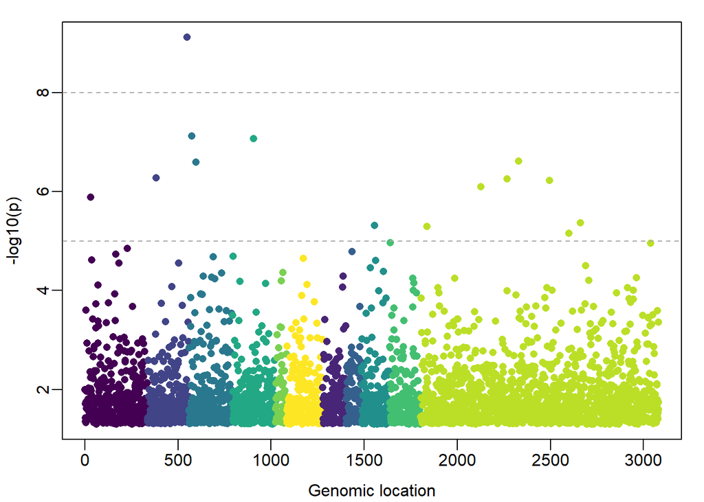

```r
# Using the R base graphics and viridis
manhattan(yieldGWAS, threshold.lines = c(5, 8))
```

```r
# tidyverse version
manhattan2 <- function(gwastab, threshold.lines = numeric(0)){
  require(dplyr)
  require(ggplot2)

  gwastab <- gwastab %>%
    arrange(Chromosome, Position) %>% # sort by chromosome and position
    filter(P.value < 0.05) %>% # filter SNPs not worth plotting (optional)
    mutate(Log10.P = -log10(P.value)) # transform P values

  gwastab$index <- 1:nrow(gwastab)

  p <- ggplot(gwastab, aes(x = index, y = Log10.P, color = factor(Chromosome))) +
    geom_point() +
    xlab("Genomic position") +
    ylab("-10log(P)") +
    scale_color_brewer(type = "qual", palette = "Paired") +
    labs(color = "Chromosome")
  # add significance threshold lines
  for(l in threshold.lines){
    p <- p + geom_hline(yintercept = l, linetype = "dashed")
  }

  # draw plot
  p
}
```

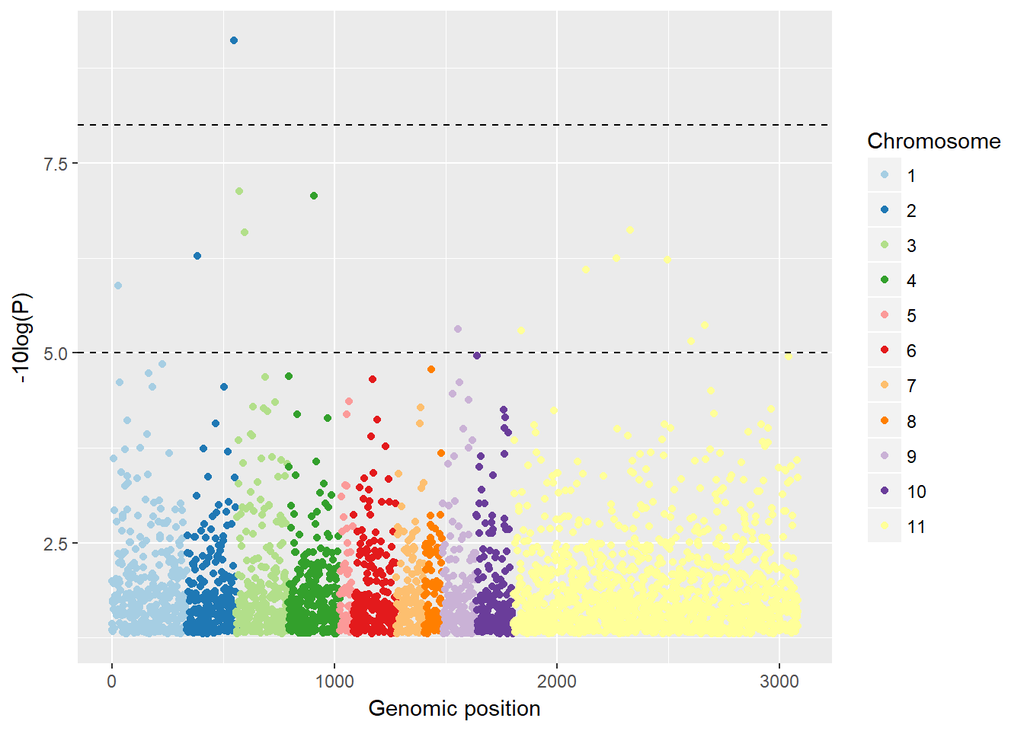

```r
# using ggplot
manhattan2(yieldGWAS, threshold.lines = c(5, 8))
```

```r
# function to make a manhattan plot from GAPIT results.
# this version uses the R base. ## fancier version.
manhattan3 <- function(gwastab, threshold.lines = numeric(0),
                       label.cutoff = 5){
  require(viridis)

  # order on genome; x values for plotting
  plotorder <- order(gwastab$Chromosome, gwastab$Position)
  gwastab <- gwastab[plotorder,]
  # filter SNPs not worth plotting (not required for full credit)
  gwastab <- gwastab[gwastab$P.value < 0.05,]
  # transform the p-values
  transp <- -log10(gwastab$P.value)

  # make colors for chromosomes
  chrnames <- sort(unique(gwastab$Chromosome))
  nchr <- length(chrnames) # number of chromosomes
  allcol <- viridis(nchr)
  # shuffle the colors (this is fancier than needed for full credit)
  allcol <- c(allcol[(1:nchr) %% 2 == 1], allcol[(1:nchr) %% 2 == 0])
  # vector for color by snp
  snpcol <- character(nrow(gwastab))
  for(i in 1:nchr){
    snpcol[gwastab$Chromosome == chrnames[i]] <- allcol[i]
  }

  # draw plot
  par(mar = c(3.1, 3.1, 1.1, 1.1), mgp = c(2, 0.5, 0))
  plot(transp, col = snpcol, pch = 16, axes = FALSE,
       xlab = "Genomic location", ylab = "-log10(p)")
  abline(h = threshold.lines, lty = 2, col = "darkgrey")
  axis(2) # add in standard y-axis

  # label points above the cutoff
  tolabel <- which(transp >= label.cutoff)
  text(tolabel, transp[tolabel], gwastab$SNP[tolabel])

  # axis with chromosome labels
  ticklocs <- numeric(nchr) # set up empty vector
  for(i in 1:nchr){
    ticklocs[i] <- median(which(gwastab$Chromosome == chrnames[i]))
  }
  axis(1, at = ticklocs, labels = as.character(chrnames))
}
```

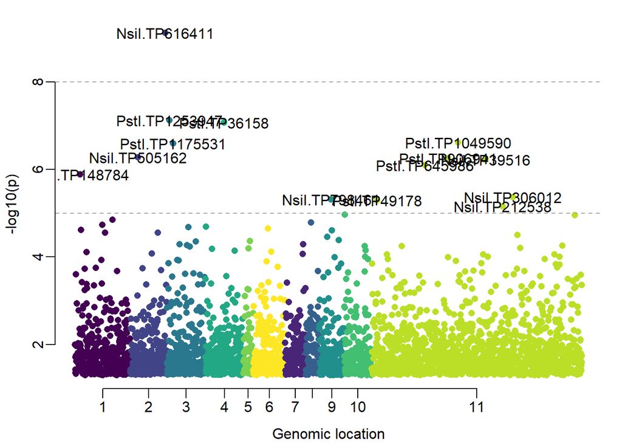

```r
# fancy version
manhattan3(yieldGWAS, threshold.lines = c(5, 8), label.cutoff = 5)
```